# STAT/MATH 495: Problem Set 09

Tasheena Narraidoo

2017-11-07

# Collaboration

Please indicate who you collaborated with on this assignment: -

# Question 1: Run k-means

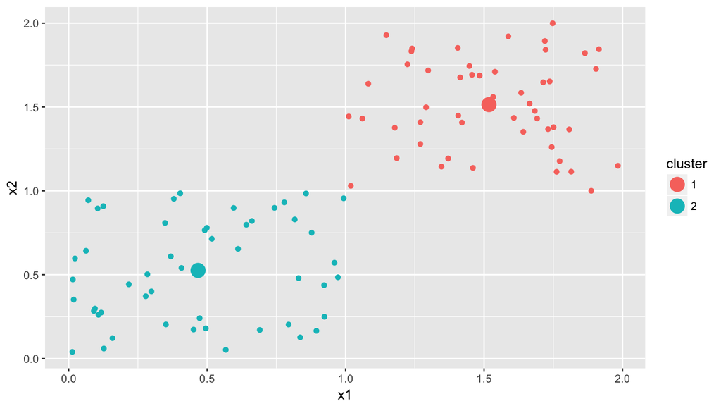

```r
observations_1 <- read_csv("data/observations_1.csv")
observations_2 <- read_csv("data/observations_2.csv")

# Set observations to be one of two datasets
observations <- observations_2

# Fit model for k=2
k <- 2
k_means_results <- kmeans(observations, centers=k)
clusters <- k_means_results$cluster
cluster_centers <- k_means_results$centers

# Add cluster results to observations. Note we convert to factor since cluster
# ID's should be treated as categorical
observations$cluster <- as.factor(clusters)

# Add cluster ID's to cluster_centers
cluster_centers <- cluster_centers %>%
  as_tibble() %>%
  mutate(cluster=as.factor(1:k))

ggplot(NULL, aes(x=x1, y=x2, col=cluster)) +
  geom_point(data=observations) +
  geom_point(data=cluster_centers, size=5)
```

**Questions**:

1. Run KMC 10 times on `observations_1` and comment on the consistency of the results.
2. Speculate on the root cause of any consistency or inconsistency in the results.
3. Run KMC 10 times on `observations_2` and comment on the consistency of the results.
4. Speculate on the root cause of any consistency or inconsistency in the results.

**Answers**:

1. On running KMC 10 times on `observations_1` we see that the results are inconsistent as the clusters have markedly different values at each run. The data points are clearly partitioned by a “line” but the slope of that line varies with no clearly defined origin.
2. The inconsistency stems from the nature of the initial random cluster assignment of the data points. The fact that the points are scattered throughout makes it difficult to have a clearly defined separation so that the cluster centers do not gravitate towards a particular location.
3. On running KMC 10 times on `observations_2` we see that the results are consistent in the sense that as at each run one cluster one is at the top right corner while the other cluster is at the bottom left corner but no cluster is clearly defined as being either cluster 1 or cluster 2 specifically at every run as they are sometimes swapped.
4. The inconsistency in the positioning of cluster 1 and cluster 2 stems from the initial random cluster assignment of the data points and the initial positioning of the cluster center. If the center of a particular cluster, say cluster 1, is closer to the top right, that cluster will be assigned as cluster 1 and the other cluster in the bottom left corner will be assigned as cluster 2 and vice versa.

# Bonus question: Code your own

Read ISLR page 388 Algorithm 10.1 and implement k-means clustering from scratch. Don’t worry about doing it for general $k$; keep it simple and do it for $k=2$ specifically. Apply it to `observations_2` from above.

```r
# Hint:
library(proxy)
A <- data_frame(
  x1 = c(0, 0.5, 0.75, 1),
  x2 = c(0, 0.5, 0.75, 1)
)
B <- data_frame(
  x1 = c(1, 0),
  x2 = c(1, 0)
)
distance_matrix <- proxy::dist(x=A, y=B)
distance_matrix
apply(distance_matrix, 1, which.min)
```

[output not shown]

```r
# Set observations to be dataset 2
A <- observations_2
n  <- nrow(A)

# Step 1 of algorithm 10.1 : Randomly assign a number to each observation from 1:k
df1 <- A %>%
  mutate(cluster =  as.factor(sample(1:2, size=n, replace=T)))

# Step 2 : Iterate until the cluster assignments stop changing:
for (i in 1:n) {
  # Step 2a : Compute cluster centroid
  c1 <- df1 %>%
    filter(cluster == 1) %>%
    summarize(x1 = mean(x1), x2 = mean(x2))

  c2 <- df1 %>%
    filter(cluster == 2) %>%
    summarize(x1 = mean(x1), x2 = mean(x2))

  B <- rbind(c1,c2)

  # Step 2b : Assign each observation to the cluster whose centroid is closest
  distance_matrix <- proxy::dist(x=A, y=B)
  cluster_reassignment <- apply(distance_matrix, 1, which.min)

  # Update the cluster re-assignment
  df1 <- df1 %>%
    mutate(cluster = as.factor(cluster_reassignment))

  # stopping criterion : two consecutive iterations generate same value
  if(i != 1 && df1 == temp){
    break
  }
  temp <- df1
}
```

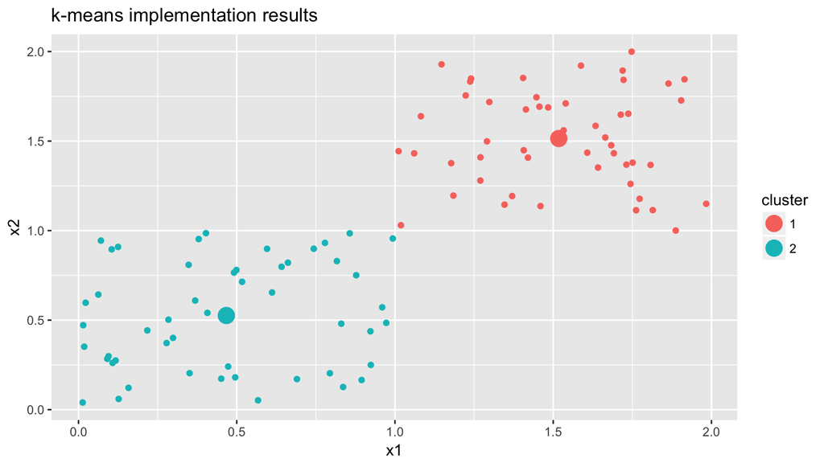

```r
# Visualizing results
# Add cluster ID's to cluster_centers
B <- B %>%
  mutate(cluster=as.factor(1:2))

# Graph results
ggplot(NULL, aes(x=x1, y=x2, col=cluster)) +
  geom_point(data=df1) +
  geom_point(data=B, size=5) +
  labs(title = "k-means implementation results")
```